# Projet Final R - La Délinquance en France

Dilane - Pascal GATIMA & Merveille Gaëlla MOUYABI

2025-05-13

## Introduction

Dans le cadre de ce projet d’étude statistique, nous avons exploité une base de données publique issue des sites du gouvernement data.gouv.fr et observatoire-des-territoires.gouv.fr, portant sur les faits de criminalité enregistrés en France au niveau régional entre 2016 et 2024. L’étude a été menée à l’aide du logiciel R Studio, permettant de traiter et visualiser les données efficacement. Nous avons particulièrement analysé trois types d’infractions pris au hasard : **les homicides**, **les tentatives d’homicides** et **le trafic de stupéfiants**. La méthodologie appliquée comprend des regroupements, des filtrages et des aggrégations par année et par région, permettant ainsi une approche à la fois temporelle et spatiale. Les analyses temporelles ont permis de mettre en évidence les tendances d’évolution annuelle, tandis que l’analyse spatiale a révélé les disparités régionales en matière de criminalité. Ce travail vise à offrir une lecture synthétique des phénomènes étudiés pour mieux en comprendre les dynamiques.

## Importation des données

Comme à chaque fois, commençons par importer notre base de données et les différentes librairies dont nous auront besoin:

```r
setwd("C:/Users/Emmaüs Connect/Documents/TD R/Projet R")

delinquance_regionale = read.table("donnee-reg-data.gouv-2024-geographie2024-produit-le2025-01-26.csv",
                                   header=TRUE,sep=";",dec=",",skip=0)
autres_variables_interessantes = read.table("data.csv", sep=";",
                                          header=TRUE, dec=".",skip=2,
                                          quote="", fill=TRUE)
library(datasets)
library(data.table)
library(tidyverse)
library(tidyr)
library(knitr)
library(ggplot2)
library(dplyr)
library(sf)
```

Nos données sont présentées en 10 variables essentielles: le *Code officiel* géographique ,l’*année* pendant laquelle la délinquance a été enregistrée, l’*Indicateur* des crimes et délits, l’*unité prise en compte* pour compter ces infractions, le *nombre* de faits, le *taux pour mille habitants* des infractions commises,la *population municipale*, l’*année de recensement de la population*, le *nombre de logements* et l’*année de recensement des logements*.

# Analyse des données

## Quelques nombres clés et évolutions constatées

```r
##Fusion des deux bases de données
names(autres_variables_interessantes)[1]="Code_region"
delinquance_fusionnée = inner_join(delinquance_regionale,
                                 autres_variables_interessantes,
                                 by ="Code_region")

##Filtrage des données selon les indicateurs traités:

###Niveau des homicides (indicateur)
nouveau = select(delinquance_fusionnée,Code_region,Libellé,indicateur,nombre,annee)
filtrage_homicides = filter(nouveau,indicateur=="Homicides")
homicides = filtrage_homicides %>%
  pivot_wider(names_from = "annee", values_from = "nombre")

##Nombre total des homicides sur 8 ans (2016-2024)
homicides_totalsur8ans = sum(sum(homicides$'2016'),
                             sum(homicides$'2017'),
                             sum(homicides$'2018'),
                             sum(homicides$'2019'),
                             sum(homicides$'2020'),
                             sum(homicides$'2021'),
                             sum(homicides$'2022'),
                             sum(homicides$'2023'),
                             sum(homicides$'2024'))

###Niveau des homicides (indicateur)
filtrage_trafic_stup = filter(nouveau,indicateur=="Trafic de stupéfiants")
trafic_stup = filtrage_trafic_stup %>%
  pivot_wider(names_from = "annee", values_from = "nombre")

trafic_stup_totalsur8ans = sum(sum(trafic_stup$'2016'),
                               sum(trafic_stup$'2017'),
                               sum(trafic_stup$'2018'),
                               sum(trafic_stup$'2019'),
                               sum(trafic_stup$'2020'),
                               sum(trafic_stup$'2021'),
                               sum(trafic_stup$'2022'),
                               sum(trafic_stup$'2023'),
                               sum(trafic_stup$'2024'))
###Niveau des tentatives d'homicides (indicateur)
filtrage_tentatives_homicides = filter(nouveau,indicateur=="Tentatives d'homicides")
tentatives_homicides = filtrage_tentatives_homicides %>%
  pivot_wider(names_from = "annee", values_from = "nombre")

tentatives_homicides_totalsur8ans = sum(sum(tentatives_homicides$'2016'),
                                        sum(tentatives_homicides$'2017'),
                                        sum(tentatives_homicides$'2018'),
                                        sum(tentatives_homicides$'2019'),
                                        sum(tentatives_homicides$'2020'),
                                        sum(tentatives_homicides$'2021'),
                                        sum(tentatives_homicides$'2022'),
                                        sum(tentatives_homicides$'2023'),
                                        sum(tentatives_homicides$'2024'))

#Tableau synthétique
table_res = data.frame(
  Indicateur = c("Homicides", "Tentatives d'homicides", "Trafic de stupéfiants"),
  Total_2016_2024 = c(homicides_totalsur8ans,
                      tentatives_homicides_totalsur8ans,
                      trafic_stup_totalsur8ans))
kable(table_res, caption = "Synthèse des infractions sur 8 ans")
```

| Indicateur | Total_2016_2024 |
| --- | --- |
| Homicides | 8048 |
| Tentatives d’homicides | 27898 |
| Trafic de stupéfiants | 415479 |

-> Le nombre **27898** représente le nombre total de tentatives d’homicides commis entre 2016 et 2024.

-> Le nombre **415479** totalise les trafics de stupéfiants mis en cause sur l’ensemble du territoire français entre 2016 et 2024. Comparée aux 2 dernières statistiques, celle-ci est frappante en raison de la différence qu’il y a entre celle-ci et les deux dernières. Il est donc compréhensible que les autorités mettent l’accent sur cette thématique afin de les réduire.

# Analyse temporelle.

## Evolution des homicides, tentatives d’homicides et des trafics de stupéfiants commis au cours du temps

Voici une représentation de l’évolution de ces trois indicateurs au cours de la période étudiée:

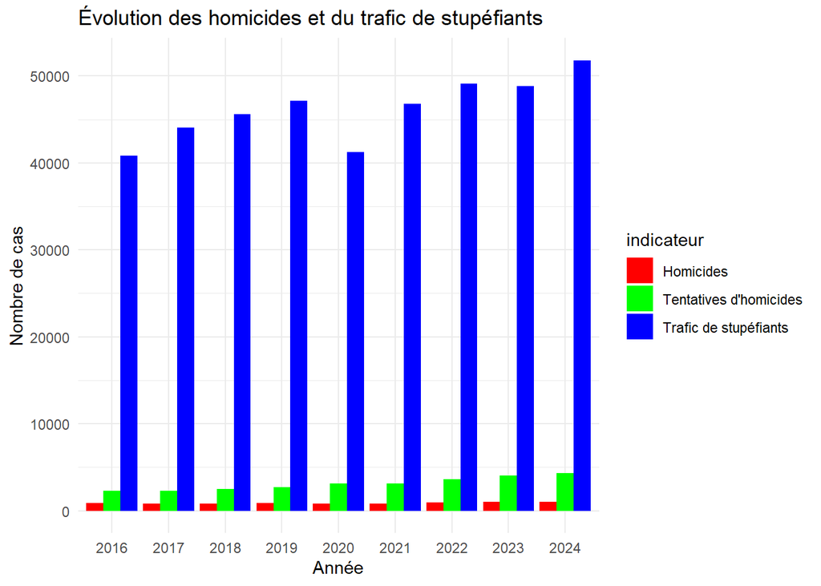

```r
##Filtrage des données suivant les indicateurs etudiés
filtrage_selonindicateurs = subset(delinquance_fusionnée,indicateur %in%
                       c("Homicides", "Tentatives d'homicides","Trafic de stupéfiants"))

##representation de l'evolution des 3 indicateurs sur la période de 8 ans
groupage_selonindicateurs = filtrage_selonindicateurs %>%
  group_by(annee, indicateur) %>%
  summarise(nombre = sum(as.numeric(nombre), na.rm = TRUE))

ggplot(groupage_selonindicateurs, aes(x = as.factor(annee), y = nombre, fill = indicateur)) +
  geom_bar(stat="identity", position="dodge")+
  scale_fill_manual(values = c("Homicides" = "red",
                               "Tentatives d'homicides" = "green",
                               "Trafic de stupéfiants" = "blue")) +
  labs(title="Évolution des homicides et du trafic de stupéfiants",
       x="Année", y="Nombre de cas") +
  theme_minimal()
```

## Evolution des 3 indicateurs sous la sphère géographique

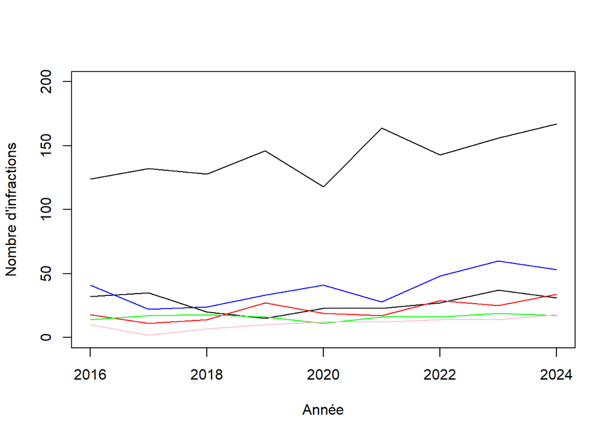

```r
plot(2016:2024,homicides[1,4:12],type="l",ylim=c(0,200),
     xlab="Année",
     ylab="Nombre d'infractions")
lines(2016:2024,homicides[2,4:12], col="red")
lines(2016:2024,homicides[3,4:12],col="blue")
lines(2016:2024,homicides[4,4:12],col="green")
lines(2016:2024,homicides[5,4:12],col="pink")
lines(2016:2024,homicides[6,4:12],col="black")
```

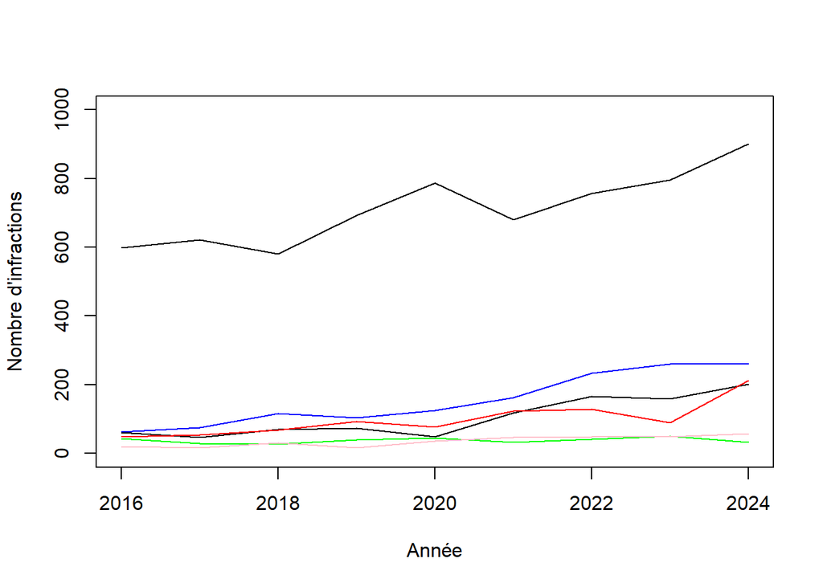

```r
## Evolution des tentatives d'homicides sur quelques regions
plot(2016:2024,tentatives_homicides[1,4:12],type="l",ylim=c(0,1000),
     xlab="Année",
     ylab="Nombre d'infractions")
lines(2016:2024,tentatives_homicides[2,4:12], col="red")
lines(2016:2024,tentatives_homicides[3,4:12],col="blue")
lines(2016:2024,tentatives_homicides[4,4:12],col="green")
lines(2016:2024,tentatives_homicides[5,4:12],col="pink")
lines(2016:2024,tentatives_homicides[6,4:12],col="black")
```

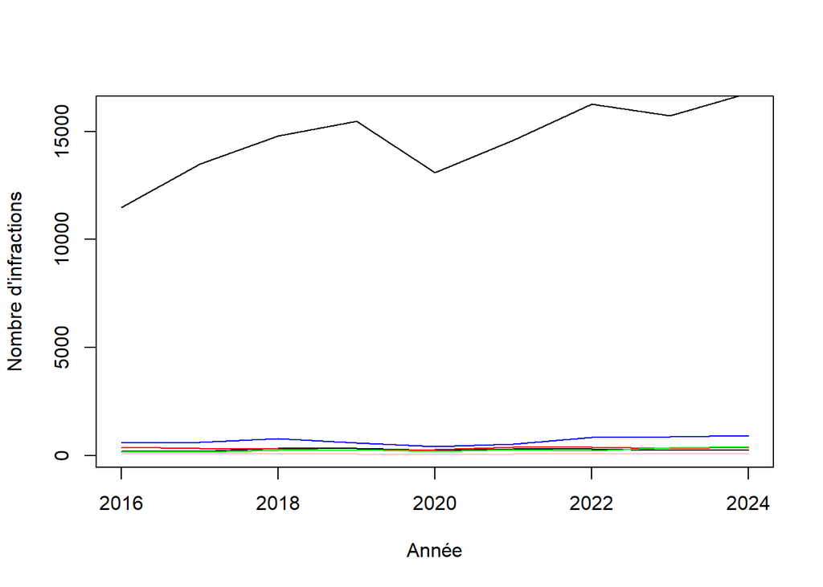

```r
## Evolution des trafics de stupéfiants sur quelques regions
plot(2016:2024,trafic_stup[1,4:12],type="l",ylim=c(100,16000),
     xlab="Année",
     ylab="Nombre d'infractions")
lines(2016:2024,trafic_stup[2,4:12], col="red")
lines(2016:2024,trafic_stup[3,4:12],col="blue")
lines(2016:2024,trafic_stup[4,4:12],col="green")
lines(2016:2024,trafic_stup[5,4:12],col="pink")
lines(2016:2024,trafic_stup[6,4:12],col="black")
```

A partir des 3 graphes précedents, on distingue clairement la tendance haussière de crimes et délits commis dans la région de l’île de France. Sur les 3 graphes, les niveaux d’infractions commis dans cette région battent tous les records et semblent ne pas s’atténuer avec le temps, au contraire, ils croissent. Pour aller plus loin, on a fait quelques calculs sur les données de la région et avons pu aboutir à:

```r
##part de l'Île de France dans les niveaux d'infractions commis
part_homicides_iledefrance = sum(homicides[6,4:12])/
  homicides_totalsur8ans
print(part_homicides_iledefrance)
```

```
## [1] 0.1587972
```

```r
part_trafic_stup_iledefrance = sum(trafic_stup[6,4:12])/
  trafic_stup_totalsur8ans
print(part_trafic_stup_iledefrance)
```

```
## [1] 0.3170485
```

```r
part_tentative_homicides_iledefrance = sum(tentatives_homicides[6,4:12])/
  tentatives_homicides_totalsur8ans
print(part_tentative_homicides_iledefrance)
```

```
## [1] 0.2299806
```

-> 15,879% qui est la part que représente l’île de France dans le total des homicides commis entre 2016 et 2024.

-> 22,998% la part de l’île de France dans l’ensemble des tentatives d’homicides commis entre 2016 et 2024.

-> et 31,704% la part de la région dans le trafic de stupéfints qui s’est fait sur la période étudiée.

Ces chiffres nous montre à quel point l’île de France tire vers le haut les niveaux de ces infractions dans leur globalité.

```r
##Evolution du trafic de stup
Evolution_traficsurlesannées=c(sum(trafic_stup$`2016`),
                               sum(trafic_stup$`2017`),
                               sum(trafic_stup$`2018`),
                               sum(trafic_stup$`2019`),
                               sum(trafic_stup$`2020`),
                               sum(trafic_stup$`2021`),
                               sum(trafic_stup$`2022`),
                               sum(trafic_stup$`2023`),
                               sum(trafic_stup$`2024`)) ##plus grand##

##Evolution des homicides
Evolution_homicidessurlesannées=c(sum(homicides$`2016`),
                               sum(homicides$`2017`),
                               sum(homicides$`2018`),
                               sum(homicides$`2019`),
                               sum(homicides$`2020`),
                               sum(homicides$`2021`),
                               sum(homicides$`2022`),
                               sum(homicides$`2023`),
                               sum(homicides$`2024`)) ##plus grand##

##Evolution des tentatives d'homicides
Evolution_tentativeshomicidessurlesannées=c(sum(tentatives_homicides$`2016`),
                                            sum(tentatives_homicides$`2017`),
                                            sum(tentatives_homicides$`2018`),
                                            sum(tentatives_homicides$`2019`),
                                            sum(tentatives_homicides$`2020`),
                                            sum(tentatives_homicides$`2021`),
                                            sum(tentatives_homicides$`2022`),
                                            sum(tentatives_homicides$`2023`),
                                            sum(tentatives_homicides$`2024`)) ##plus grand##))
```

## Evolution des 3 indicateurs sur la période

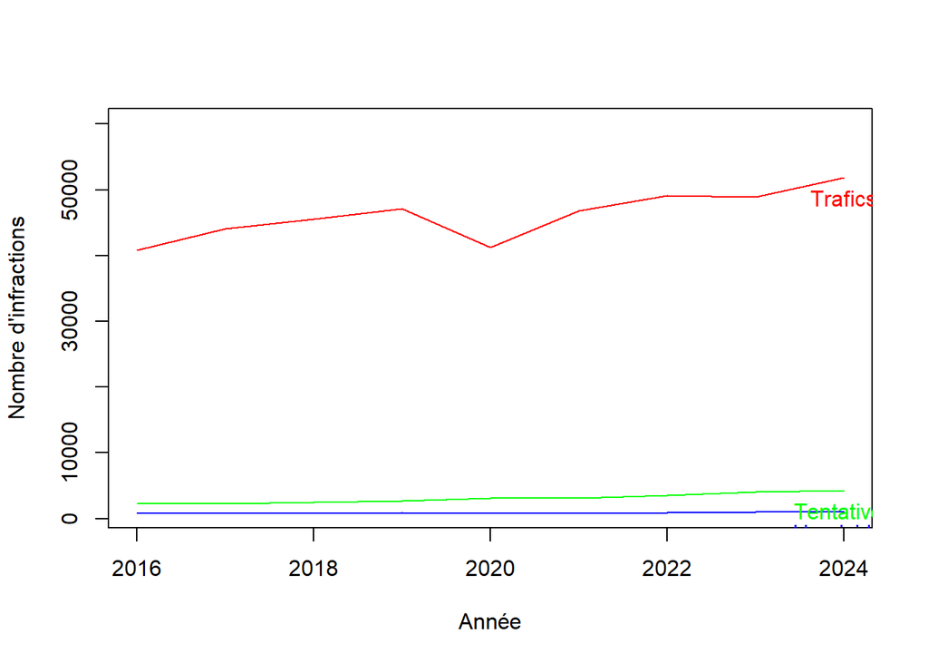

```r
##Representation de l'evolution des 3 indicteurs
plot(2016:2024,Evolution_traficsurlesannées,type="l",ylim=c(1000,60000),
     xlab="Année",
     ylab="Nombre d'infractions",col="red")
lines(2016:2024, Evolution_homicidessurlesannées, col="blue")
lines(2016:2024, Evolution_tentativeshomicidessurlesannées, col="green")
text(2024, Evolution_traficsurlesannées[length(Evolution_traficsurlesannées)], "Trafics", col="red", pos=1)
text(2024, Evolution_homicidessurlesannées[length(Evolution_homicidessurlesannées)], "Homicides", col="blue", pos=1)
text(2024, Evolution_tentativeshomicidessurlesannées[length(Evolution_tentativeshomicidessurlesannées)], "Tentatives", col="green", pos=1)
```

# Analyse spatiale.

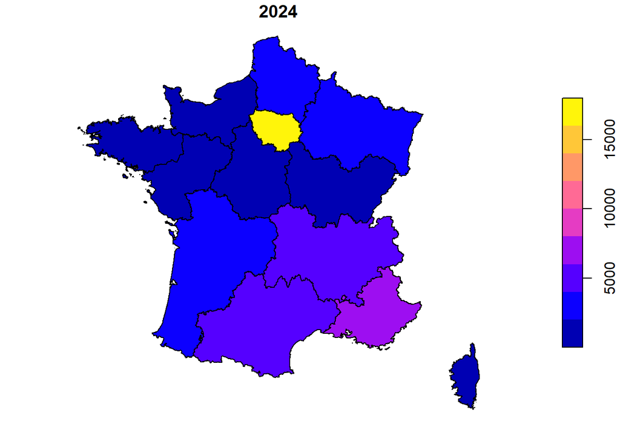

```r
##Représentation cartographiée

#niveau du trafic des stupefiants
carte = read_sf("REGION.shp")
names(carte)[6]="Code_region"
carte$Code_region = as.numeric(carte$INSEE_REG)
fusion_traficstup_carte = left_join(carte, trafic_stup, by ="Code_region")

plot(fusion_traficstup_carte["2024"])
```

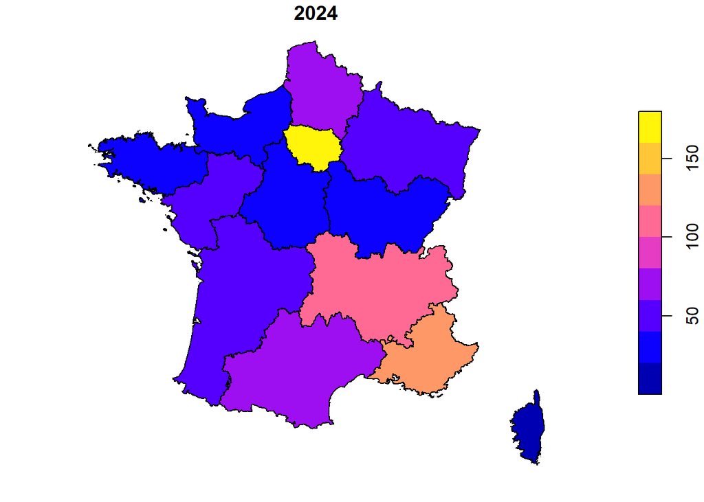

```r
#niveau des homicides
fusion_homicides_carte = left_join(carte, homicides, by ="Code_region")

plot(fusion_homicides_carte["2024"])
```

A travers ces différentes cartes, on se rend compte de la répartition territoriale des infractions commises sur l’espace et de leur ampleur (grâce aux couleurs). A chaque fois, on remarque l’accentuation de cette répartition sur la région d’**Île de France**. Les raisons à ce niveau de délinquance peuvent être associées à la forte densité de la population (la plus importante dans toute la France ) et aux disparités socio-économiques très élevées (les inégalités et la précarité sont très importants).

Vérifions ces corrélations par une mise en relation des variables de la base de données:

```r
# Vérification de la corrélation avec le taux de chômage
cor_chomage_infraction = cor(delinquance_fusionnée$Taux.de.chômage.des.15.24.ans..RP..2021[which(delinquance_fusionnée$annee<=2021)],
                             delinquance_fusionnée$nombre[which(delinquance_fusionnée$annee<=2021)], use="complete.obs")

# Vérification de la corrélation avec la densité de la population
cor_densitépop_infraction = cor(delinquance_fusionnée$Densité.de.population.2021[which(delinquance_fusionnée$annee<=2021)],
                          delinquance_fusionnée$nombre[which(delinquance_fusionnée$annee<=2021)], use="complete.obs")

print(paste("Corrélation taux de chômage - infractions :", cor_chomage_infraction))
```

```
## [1] "Corrélation taux de chômage - infractions : -0.24205412457631"
```

```r
print(paste("Corrélation densité de la population - infractions :", cor_densitépop_infraction))
```

```
## [1] "Corrélation densité de la population - infractions : 0.388854872753872"
```

Ces deux nombres nous montrent que le niveau de la population (densité) et de chômage d’une région influe faiblement sur son niveau de criminalité pour l’ensemble des régions étudiées. Ces variables ont un lien de causalité entre elles très faible voir nul.

## Conclusion

Cette étude met en lumière une criminalité en forte évolution, notamment pour le trafic de stupéfiants, qui devient une priorité pour les autorités. L’Île-de-France est un point central de la délinquance, mais la relation avec la densité ou le chômage reste faible. Les décisions publiques devront donc s’orienter vers des stratégies spécifiques pour endiguer ces phénomènes et adapter les politiques de sécurité.

## Références

Bases de données de la délinquance en France: **“https://www.data.gouv.fr/fr/datasets/bases-statistiques-communale-departementale-et-regionale-de-la-delinquance-enregistree-par-la-police-et-la-gendarmerie-nationales/”**

Bases de données de “certaines variables intéressantes”: **“https://www.observatoire-des-territoires.gouv.fr/outils/cartographie-interactive/#c=indicator&view=map72”**